# Data Exploration - Heart Disease Dataset

```python
# Importing required dataset
import pandas as pd
import numpy as np
import matplotlib.pyplot as plt
import seaborn as sns
import warnings
warnings.filterwarnings("ignore")
```

```python
import os
os.chdir("C:\\Users\\Jeeva46\\Desktop\\GIT\\Heart_disease\\")
```

```python
# Reading the file and Displaying
df = pd.read_csv("heart_data.csv")
df.head()
```

|  | HeartDisease | BMI | Smoking | AlcoholDrinking | Stroke | PhysicalHealth | MentalHealth | DiffWalking | Sex | AgeCategory | Race | Diabetic | PhysicalActivity | GenHealth | SleepTime | Asthma | KidneyDisease | SkinCancer |
| --- | --- | --- | --- | --- | --- | --- | --- | --- | --- | --- | --- | --- | --- | --- | --- | --- | --- | --- |
| 0 | No | 16.60 | Yes | No | No | 3.0 | 30.0 | No | Female | 55-59 | White | Yes | Yes | Very good | 5.0 | Yes | No | Yes |
| 1 | No | 20.34 | No | No | Yes | 0.0 | 0.0 | No | Female | 80 or older | White | No | Yes | Very good | 7.0 | No | No | No |
| 2 | No | 26.58 | Yes | No | No | 20.0 | 30.0 | No | Male | 65-69 | White | Yes | Yes | Fair | 8.0 | Yes | No | No |
| 3 | No | 24.21 | No | No | No | 0.0 | 0.0 | No | Female | 75-79 | White | No | No | Good | 6.0 | No | No | Yes |
| 4 | No | 23.71 | No | No | No | 28.0 | 0.0 | Yes | Female | 40-44 | White | No | Yes | Very good | 8.0 | No | No | No |

```python
# Dimension of the data
df.shape
```

```
(319795, 18)
```

319795 values , 18 Features

```python
# Getting info on the data
df.info()
```

```
<class 'pandas.core.frame.DataFrame'>
RangeIndex: 319795 entries, 0 to 319794
Data columns (total 18 columns):
 #   Column            Non-Null Count   Dtype
---  ------            --------------   -----
 0   HeartDisease      319795 non-null  object
 1   BMI               319795 non-null  float64
 2   Smoking           319795 non-null  object
 3   AlcoholDrinking   319795 non-null  object
 4   Stroke            319795 non-null  object
 5   PhysicalHealth    319795 non-null  float64
 6   MentalHealth      319795 non-null  float64
 7   DiffWalking       319795 non-null  object
 8   Sex               319795 non-null  object
 9   AgeCategory       319795 non-null  object
 10  Race              319795 non-null  object
 11  Diabetic          319795 non-null  object
 12  PhysicalActivity  319795 non-null  object
 13  GenHealth         319795 non-null  object
 14  SleepTime         319795 non-null  float64
 15  Asthma            319795 non-null  object
 16  KidneyDisease     319795 non-null  object
 17  SkinCancer        319795 non-null  object
dtypes: float64(4), object(14)
memory usage: 43.9+ MB
```

```python
# CHecking the null values
df.isnull().sum()
```

```
HeartDisease        0
BMI                 0
Smoking             0
AlcoholDrinking     0
Stroke              0
PhysicalHealth      0
MentalHealth        0
DiffWalking         0
Sex                 0
AgeCategory         0
Race                0
Diabetic            0
PhysicalActivity    0
GenHealth           0
SleepTime           0
Asthma              0
KidneyDisease       0
SkinCancer          0
dtype: int64
```

```python
# Checking the duplicates on dataset
df.duplicated().sum()
```

```
18078
```

```python
# Dropping Duplicates
df.drop_duplicates(inplace=True)
df.duplicated().sum()
```

```
0
```

```python
# Checking The count of variables in feature to determine the Discrete and numerical variables
df.nunique()
```

```
HeartDisease           2
BMI                 3604
Smoking                2
AlcoholDrinking        2
Stroke                 2
PhysicalHealth        31
MentalHealth          31
DiffWalking            2
Sex                    2
AgeCategory           13
Race                   6
Diabetic               4
PhysicalActivity       2
GenHealth              5
SleepTime             24
Asthma                 2
KidneyDisease          2
SkinCancer             2
dtype: int64
```

# Data Cleaning

```python
# Droping the unwanted columns
df.drop(columns=['Race'],axis=1,inplace=True)
```

```python
# Importing Labelencoder and encoding into numerical
from sklearn.preprocessing import LabelEncoder

le = LabelEncoder()

cat_columns = ['HeartDisease',
 'Smoking',
 'AlcoholDrinking',
 'Stroke',
 'DiffWalking',
 'Sex',
 'Diabetic',
 'PhysicalActivity',
 'GenHealth',
 'Asthma',
 'KidneyDisease',
 'SkinCancer']

for col in cat_columns:
    df[col] = le.fit_transform(df[col])

df.info()
```

```
<class 'pandas.core.frame.DataFrame'>
Int64Index: 301717 entries, 0 to 319794
Data columns (total 17 columns):
 #   Column            Non-Null Count   Dtype
---  ------            --------------   -----
 0   HeartDisease      301717 non-null  int32
 1   BMI               301717 non-null  float64
 2   Smoking           301717 non-null  int32
 3   AlcoholDrinking   301717 non-null  int32
 4   Stroke            301717 non-null  int32
 5   PhysicalHealth    301717 non-null  float64
 6   MentalHealth      301717 non-null  float64
 7   DiffWalking       301717 non-null  int32
 8   Sex               301717 non-null  int32
 9   AgeCategory       301717 non-null  object
 10  Diabetic          301717 non-null  int32
 11  PhysicalActivity  301717 non-null  int32
 12  GenHealth         301717 non-null  int32
 13  SleepTime         301717 non-null  float64
 14  Asthma            301717 non-null  int32
 15  KidneyDisease     301717 non-null  int32
 16  SkinCancer        301717 non-null  int32
dtypes: float64(4), int32(12), object(1)
memory usage: 27.6+ MB
```

```python
# Categorizing the age column to discrete categorical and numerical for modeling
age_cat= {
    '18-24':0,'25-29':1,'30-34':1,'35-39':1,
    '40-44':2,'45-49':2,'50-54':2,'55-59':3,
    '60-64':3,'65-69':3,'70-74':4,'75-79':4,'80 or older':4
}
df['AgeCategory'] = df['AgeCategory'].replace(age_cat)

print(df['AgeCategory'].unique())
```

```
[3 4 2 0 1]
```

```python
df.describe(include='all').T
```

|  | count | mean | std | min | 25% | 50% | 75% | max |
| --- | --- | --- | --- | --- | --- | --- | --- | --- |
| HeartDisease | 301717.0 | 0.090353 | 0.286687 | 0.00 | 0.00 | 0.00 | 0.00 | 1.00 |
| BMI | 301717.0 | 28.441970 | 6.468134 | 12.02 | 24.03 | 27.41 | 31.65 | 94.85 |
| Smoking | 301717.0 | 0.422267 | 0.493921 | 0.00 | 0.00 | 0.00 | 1.00 | 1.00 |
| AlcoholDrinking | 301717.0 | 0.071527 | 0.257704 | 0.00 | 0.00 | 0.00 | 0.00 | 1.00 |
| Stroke | 301717.0 | 0.039984 | 0.195923 | 0.00 | 0.00 | 0.00 | 0.00 | 1.00 |
| PhysicalHealth | 301717.0 | 3.572298 | 8.140656 | 0.00 | 0.00 | 0.00 | 2.00 | 30.00 |
| MentalHealth | 301717.0 | 4.121475 | 8.128288 | 0.00 | 0.00 | 0.00 | 4.00 | 30.00 |
| DiffWalking | 301717.0 | 0.147009 | 0.354115 | 0.00 | 0.00 | 0.00 | 0.00 | 1.00 |
| Sex | 301717.0 | 0.470792 | 0.499147 | 0.00 | 0.00 | 0.00 | 1.00 | 1.00 |
| AgeCategory | 301717.0 | 2.475240 | 1.220565 | 0.00 | 2.00 | 3.00 | 3.00 | 4.00 |
| Diabetic | 301717.0 | 0.316926 | 0.732372 | 0.00 | 0.00 | 0.00 | 0.00 | 3.00 |
| PhysicalActivity | 301717.0 | 0.763669 | 0.424828 | 0.00 | 1.00 | 1.00 | 1.00 | 1.00 |
| GenHealth | 301717.0 | 2.221217 | 1.511502 | 0.00 | 1.00 | 2.00 | 4.00 | 4.00 |
| SleepTime | 301717.0 | 7.084559 | 1.467122 | 1.00 | 6.00 | 7.00 | 8.00 | 24.00 |
| Asthma | 301717.0 | 0.141361 | 0.348394 | 0.00 | 0.00 | 0.00 | 0.00 | 1.00 |
| KidneyDisease | 301717.0 | 0.039030 | 0.193667 | 0.00 | 0.00 | 0.00 | 0.00 | 1.00 |
| SkinCancer | 301717.0 | 0.097084 | 0.296073 | 0.00 | 0.00 | 0.00 | 0.00 | 1.00 |

# Data analysis with Visualization

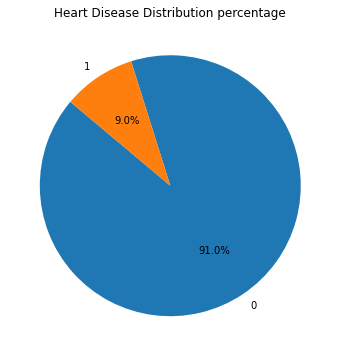

```python
# Data distribution of Target variable

# Count the occurrences of each category
category_counts = df['HeartDisease'].value_counts()

# Extract labels and sizes for the pie plot
labels = category_counts.index.tolist()
sizes = category_counts.values.tolist()

# Plotting the pie chart
plt.figure(figsize=(6, 6))
plt.pie(sizes, labels=labels, autopct='%1.1f%%', startangle=140)
plt.title('Heart Disease Distribution percentage')
plt.show()
```

- This shows that this Dataset is of imbalanced dataset we cant extract high accuracy of prediction from this Dataset

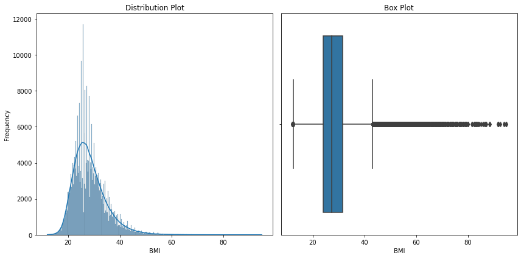

```python
# Distribution of BMI variable
fig, axs = plt.subplots(1, 2, figsize=(12, 6))

# Distribution plot (left subplot)
sns.histplot(df['BMI'], kde=True, ax=axs[0])
axs[0].set_title('Distribution Plot')
axs[0].set_xlabel('BMI')
axs[0].set_ylabel('Frequency')

# Box plot (right subplot)
sns.boxplot(df['BMI'], ax=axs[1])
axs[1].set_title('Box Plot')
axs[1].set_xlabel('BMI')

# Adjust layout to prevent overlap
plt.tight_layout()
plt.show()
```

- BMI has high outliers and need to be treated
- Distribution between 20-35 is Higher
- data is righ skewed

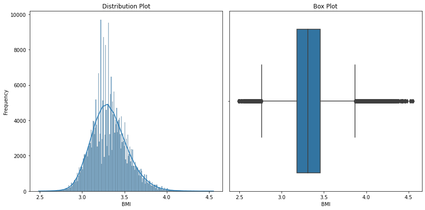

```python
# Normalizing the BMI feature to log(BMI)
df['BMI'] = np.log(df['BMI'])
# Distribution of BMI variable
fig, axs = plt.subplots(1, 2, figsize=(12, 6))

# Distribution plot (left subplot)
sns.histplot(df['BMI'], kde=True, ax=axs[0])
axs[0].set_title('Distribution Plot')
axs[0].set_xlabel('BMI')
axs[0].set_ylabel('Frequency')

# Box plot (right subplot)
sns.boxplot(df['BMI'], ax=axs[1])
axs[1].set_title('Box Plot')
axs[1].set_xlabel('BMI')

# Adjust layout to prevent overlap
plt.tight_layout()
plt.show()
```

- after treating with np.log to avoid saturating the data

```python
# Identify categorical columns
categorical_cols = ['HeartDisease', 'Smoking', 'AlcoholDrinking', 'Stroke', 'DiffWalking', 'Sex',
 'AgeCategory','Diabetic','PhysicalActivity','GenHealth', 'Asthma', 'KidneyDisease', 'SkinCancer']
```

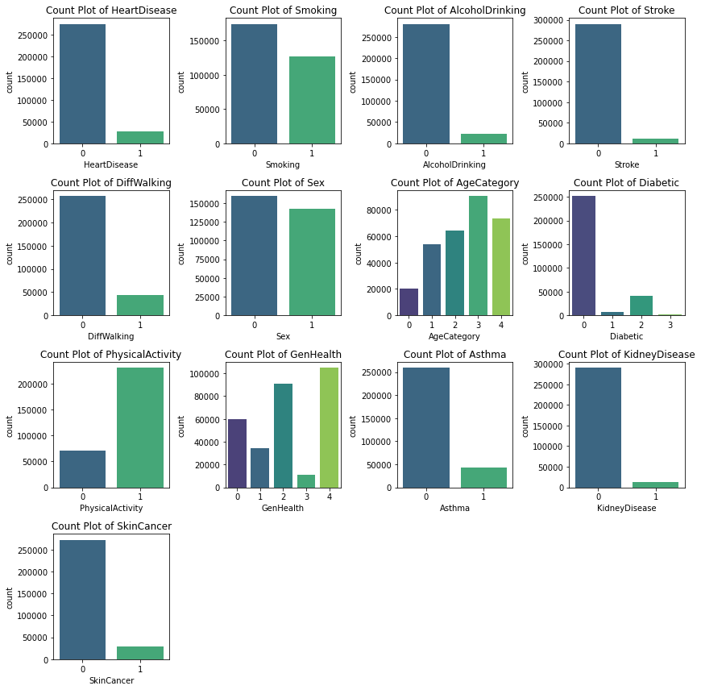

```python
num_rows = 4
num_cols = (len(categorical_cols) + num_rows - 1) // num_rows  # Ensure enough columns to fit all plots

# Create subplots
fig, axs = plt.subplots(num_rows, num_cols, figsize=(3*num_cols, 3*num_rows))

# Flatten the axs array for easy iteration
axs = axs.flatten()

# Plot count plots
for i, col in enumerate(categorical_cols):
    sns.countplot(x=col, data=df, ax=axs[i], palette='viridis')
    axs[i].set_title(f'Count Plot of {col}')

# Remove any unused subplots
for j in range(i + 1, len(axs)):
    fig.delaxes(axs[j])

# Adjust layout
plt.tight_layout()
plt.show()
```

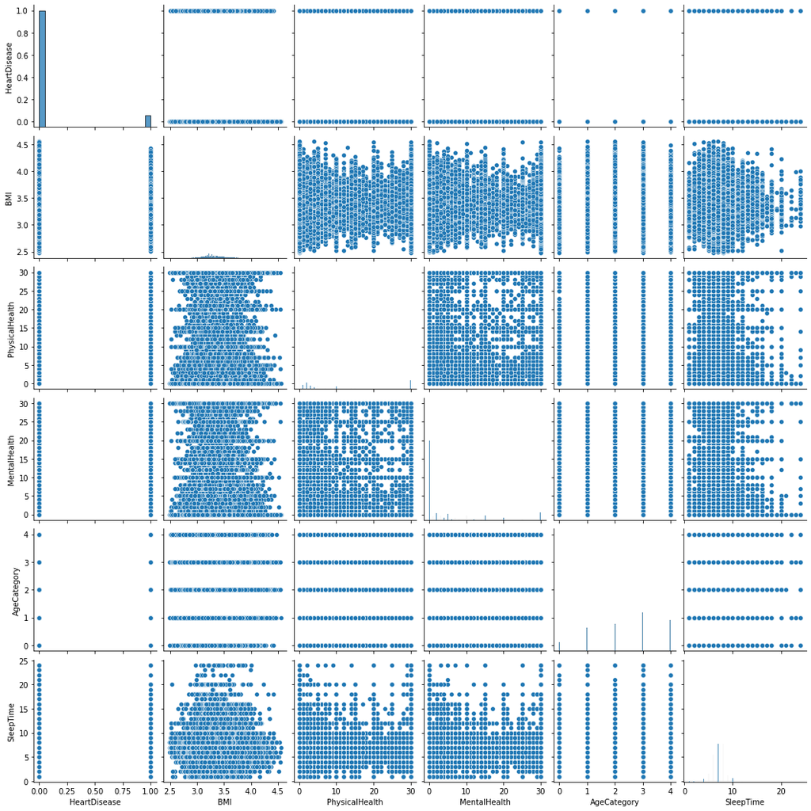

```python
# Visualizing pairplot with numerical to Target variable
pairplot = df[['HeartDisease','BMI','PhysicalHealth','MentalHealth','AgeCategory','SleepTime']]
sns.pairplot(pairplot)
plt.show()
```

- Pair plot helps to view any relationship visible via visual

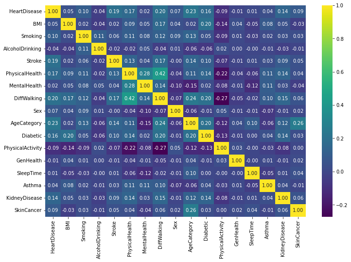

```python
# Heatmap on corelation among variables
corr = df.corr()

plt.figure(figsize=(12,8))
sns.heatmap(corr,annot=True,fmt='.2f',cmap='viridis')
plt.show()
```

- Corelation value is shown and we can drop the variable with low corelation
- to have high integrity dataframe

```python
# Dropping the column with low corelation for high integrity
df.drop(columns=['BMI','GenHealth','SleepTime','MentalHealth','AlcoholDrinking','Asthma','PhysicalActivity'],inplace=True)
```

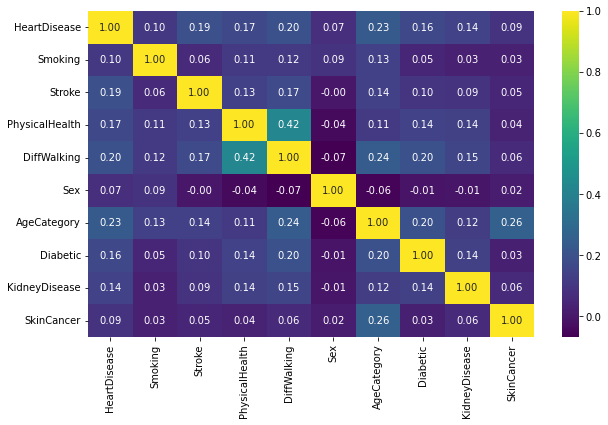

```python
# Checking for new set for Multicolinearity
corr = df.corr()

plt.figure(figsize=(10,6))
sns.heatmap(corr,annot=True,fmt='.2f',cmap='viridis')
plt.show()
```